# Why Does the Unit Cost of YEKDEM Increase?

Alkım Can Çelik

02.08.2019

Codes can be accessed via this [link.](https://alkimcelik.github.io/Rise_In_Unit_Cost_of_YEKDEM_Codes.html)

## Contents

1. Introduction
2. Key Takeaways
3. Comparisons
   1. Market Clearing Price (PTF) - Unit Cost
   2. Total Cost (YEKTOB) and Total Production Distributions in terms of Renewable Resources
   3. EPDK Forecasts for Unit Cost - Real Unit Cost
   4. Weighted Average of USD - TRY and Unit Cost
   5. Withdrawal Quantity Under Supply Liability (UEÇM) - Unit Cost
   6. The Amount of Hydro Power Plants’ Production - Unit Cost
4. Conclusion
5. References
6. About the Author

## Introduction

This report has been prepared to investigate reasons of the rise in the unit cost of renewables support mechanism (YEKDEM) from February 2019 to April 2019. Throughout the report, “rise in the unit cost” means “rise in the unit cost of renewables support mechanism from February to May 2019”.

## Key Takeaways

- The average of unit cost in 6 months has been roughly doubled between second half of 2018 (54.70 TL) and first half of 2019 (107.98 TL).
- As expected, the main reason of the rise in the unit cost of YEKDEM between January 2019 and May 2019 is a significant increase in hydro power plants’ production at the same time.
- Weighted monthly average of market clearing price (piyasa takas fiyatı) tends to decrease from September 2018 to the present time. This decline in the market clearing price should be one of the reasons of the rise in the unit cost.
- When expenses for renewable resources and earnings from these are analyzed, hydro power plants and wind turbines are more efficient than the other renewable resources.
- EPDK (Enerji Piyasası Düzenleme Kurumu) generally forecasts the unit cost less than the real unit cost. However, EPDK could predict the rise in the unit cost.
- Weighted monthly average of USD - TRY exchange rate has affected the unit cost at some points. However, it is not the most effective factor of the rise in the unit cost.

## Comparisons

In this section, the unit cost is compared with some features which constitute the formula of the unit cost.

#### 1) Market Clearing Price (PTF) - Unit Cost

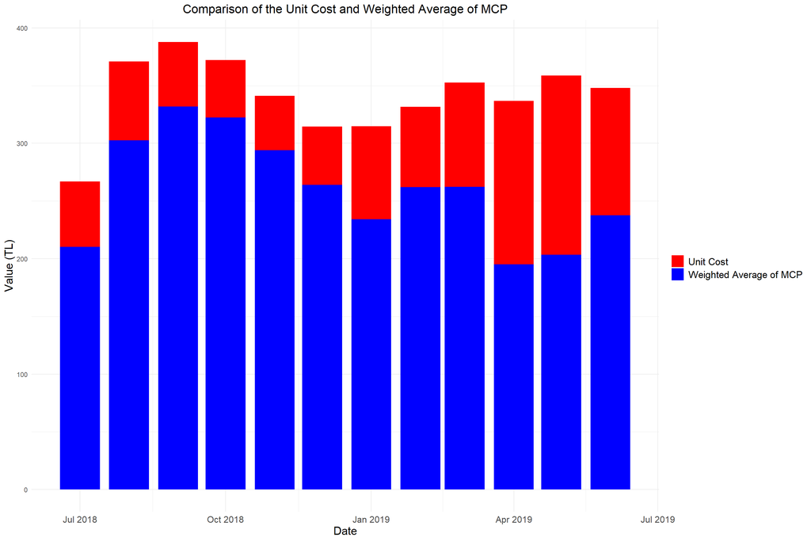

In this report, weighted average of market clearing price was calculated according to hourly matched bids and offers.

It can be seen clearly that market clearing price has tended to decrease since September 2018. Since negative correlation exists between market clearing price and the unit cost, rise in the unit cost should be expected. However, this effect does not show up suddenly. The unit cost had been diminished from September 2018 until November 2018. There must be some other reasons having strong impacts on the unit cost.

After November, effects of decrease in market clearing price can be realized obviously. In most monthly periods after November, negative correlation between them can be clearly seen from the graph above. Especially, between February 2019 and May 2019, as market clearing prices significantly had been decreased, the unit cost had been increased significantly too.

To sum up, decrease in market clearing price between February 2019 and May 2019 can be regarded as one of the reasons of the rise in the unit cost.

#### 2) Total Cost (YEKTOB) and Total Production Distributions in terms of Renewable Resources

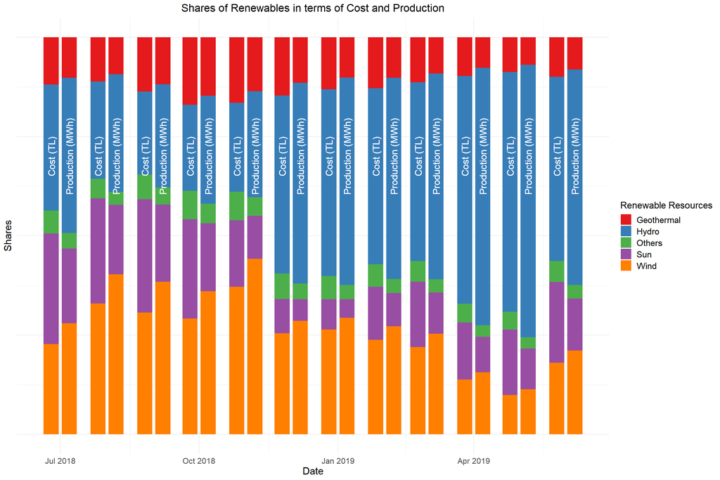

This graph is plotted in order to compare costs of renewable resources and the amount of production from them. It shows how total cost and production are distributed in respect to renewables resources. Colorful parts indicate the shares of these resources. Renewable resources labeled as “Others” include land fill gas, biogas, and biomass. While the graph was preparing, production shares of renewable resources are calculated with no regard to renewables’ tolerance coefficients.

First, wind and hydro power plants are more efficient than the others. Their production shares have exceeded the cost shares since July 2018, which means profit rates from them have been higher than the others.

Second, cost and production ratios of hydro power plants had increased from November 2018 to May 2019 due to the rise in rainfall in this period. Moreover, in this time, cost and production ratios of wind power plants had decreased. Cost and production ratios of solar power plants had also diminished in winter, as expected. There is no significant change in cost and production ratios of the others because they are not affected from climate conditions.

From August 2018 to November 2018, wind energy had the biggest piece of both cost and production cakes. However, this situation has changed after November 2018. Cost and production ratios of hydro power plants have increased significantly, and become the highest.

#### 3) EPDK Forecasts for Unit Cost - Real Unit Cost

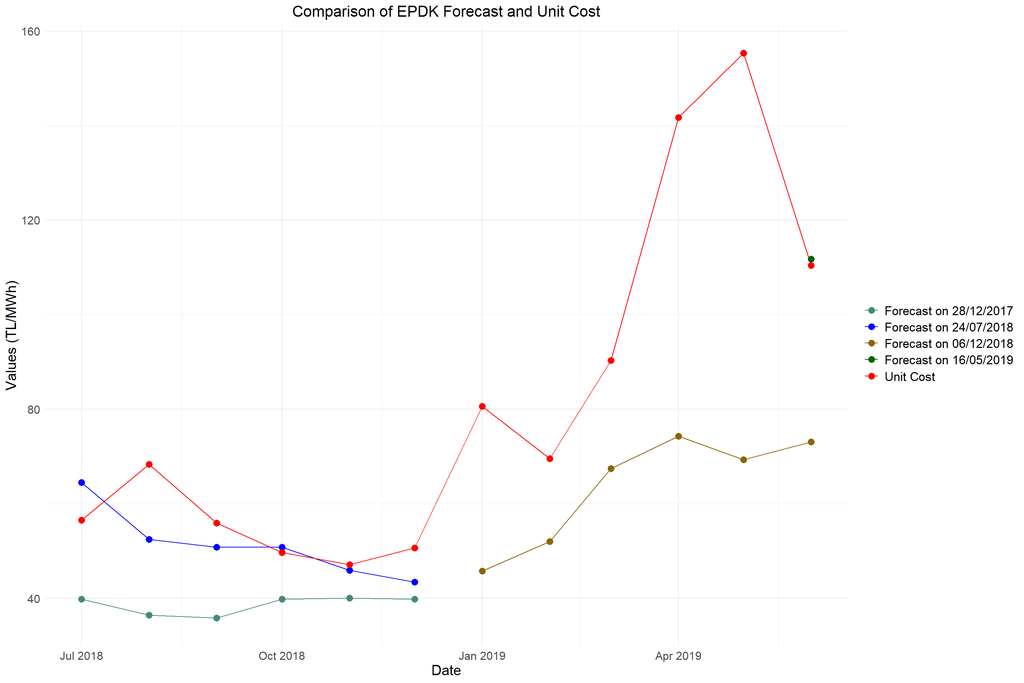

EPDK (Enerji Piyasası Düzenleme Kurulu) forecasts the unit cost annually. As shown in the graph, EPDK is not successful predicting the unit cost when it predicts at tne beginning of the year. Its predictions are always lower than the real unit cost interestingly. Nevertheless, it can predict fairly well whether the unit cost increases.

When it updates their forecasts for the unit cost, its updated predictions are closer to the real unit cost than the old predictions, as expected. However, its predictions are far away if sudden rises or declines in the unit cost occur. EPDK did forecast very well October and November 2018, and June 2019.

Interestingly, EPDK updated its prediction for July 2018 not well although the real unit cost was announced after a month. However, this situation is not valid for updating 2019. EPDK updated June 2019 very well.

It did forecast the rise in the unit cost between February and April 2019, but the rise in its prediction is not as much as the real rise in the unit cost in this period. Its prediction for April 2019 is almost half of the real unit cost in this month.

EPDK’s predictions between October and December in 2018 are close to the unit cost compared to the other months in data.

#### 4) Weighted Average of USD - TRY and Unit Cost

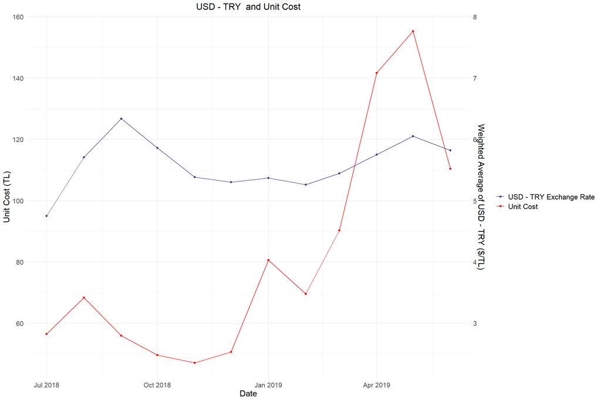

In this report, weighted average of USD - TRY exchange rate was calculated according to the quantity of hourly production from renewable resources.

USD - TRY exchange rate has a positive correlation with the unit cost due to total cost (YEKTOB) formula. However, there are also some exceptions. For instance, exchange rate had increased significantly from August 2018 to September 2018, but the unit cost decreased surprisingly in this period.

From February 2019 to May 2019, as the unit cost had increased, exchange rate had also increased, but not as much as the unit cost. In general, their rising trends are similar to each other.

To sum up, both exchange rate and the unit cost have tended to increase last year. They are positively correlated each other. However, the significant rise in the unit cost between February 2019 and May 2019 cannot entirely be explained by the rise in weighted average of USD - TRY. Other reasons must affect more than weighted average of USD - TRY.

#### 5) Withdrawal Quantity Under Supply Liability (UEÇM) - Unit Cost

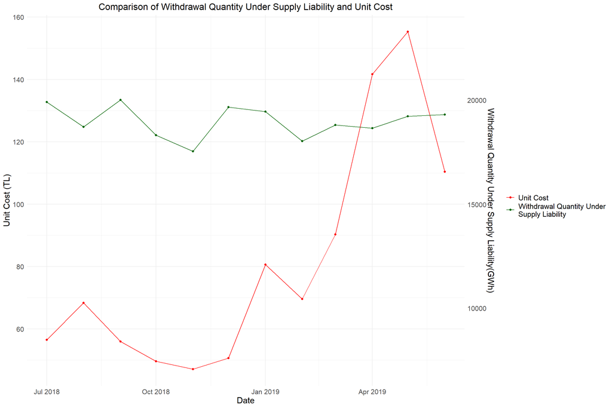

Withdrawal quantity under supply liability (Tedarik Yükümlülüğü Kapsamındaki UEÇM) is one of the key factors in calculation of the unit cost. Rise in the unit cost depends on either increase in total cost or decrease in withdrawal quantity under supply liability, which means correlation of the unit cost and withdrawal quantity under supply liability is negative.

When the graph above is analyzed, generally, reality has not fitted the rules of mathematics. From July 2018 to September 2018, negative correlation can be clearly seen, but after September, they have been generally in the same direction interestingly.

When the rise in the unit cost had happened, withdrawal quantity under supply liablility had not changed significantly. In fact, it had slightly increased in overall. Between March and April 2019, which is the time interval the highest rise in the unit cost occurs, withdrawal quantity under supply liability had decreased a little.

Finally, the unit cost has been affected from total cost more than withdrawal quantity under supply liablility since July 2018. Behaviour of Withdrawal quantity under supply liability last year cannot be an explanation for the rise in the unit cost.

#### 6) The Amount of Hydro Power Plants’ Production - Unit Cost

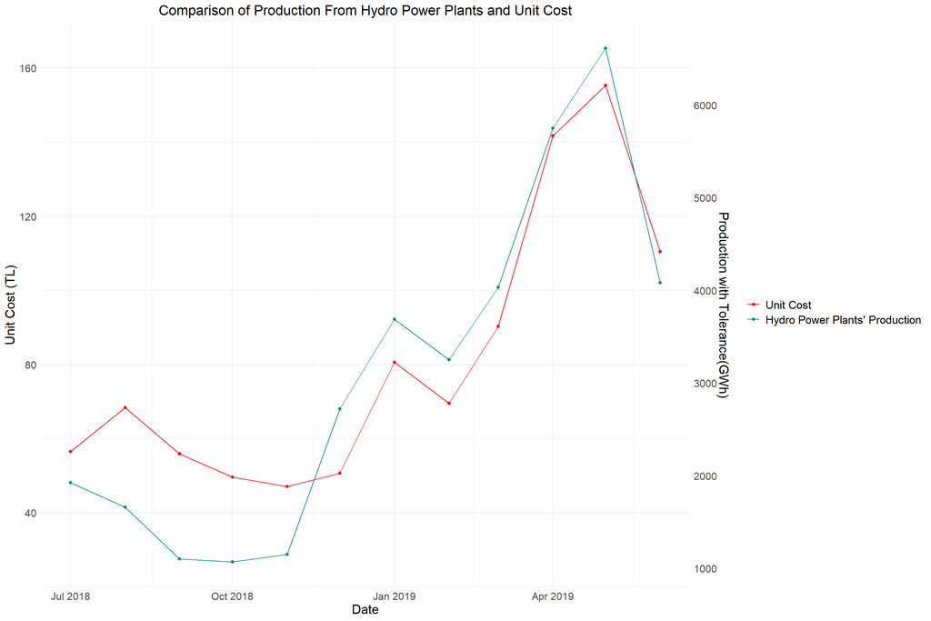

Hydro power plants (HES) play a significance role between renewable sources, which can be understood from the second graph of the report. Especially in spring, the amount of production from hydro power plants can exceed 50 percent of total production from all renewable resources.

It can be clearly seen from the graph that the amount of production from hydro power plants has been highly correlated with the unit cost after December 2018. All rises and declines are common for each month. Slopes of the lines are also very similar.

Due to snow melting and rise in rainfalls, the amount of production from hydro power plants increases significantly, as well total production from renewabe resources in spring. Therefore, since the other factors had been steady or slightly beneficial for the unit cost, increase in level of dams had directly affected the unit cost positively.

To sum up, the rise in the unit cost depends highly on the amount of production from hydro power plants because hydro power plants have a big share among renewable resources.

## References

https://seffaflik.epias.com.tr/transparency/tuketim/gerceklesen-tuketim/tedarik-yukumlulugu-kapsamindaki-uecm.xhtml

https://seffaflik.epias.com.tr/transparency/uretim/yekdem/lisansli-uretim-miktari/yekdem-lisansli-gercek-zamanli-uretim.xhtml

https://seffaflik.epias.com.tr/transparency/uretim/yekdem/lisanssiz-uretim-miktari.xhtml

https://evds2.tcmb.gov.tr/index.php?/evds/serieMarket/#collapse_2

https://seffaflik.epias.com.tr/transparency/uretim/yekdem/birim-maliyeti.xhtml

https://seffaflik.epias.com.tr/transparency/piyasalar/gop/ptf.xhtml

https://yesilekonomi.com/epdk-2019-tahmini-yekdem-maliyetlerini-acikladi/

https://www.enerjigunlugu.net/epdk-2018-yekdem-maliyetlerini-acikladi-25513h.htm

http://www.resmigazete.gov.tr/eskiler/2016/04/20160429-8.htm

https://www.afaenerji.com/yekdem-maliyetlerini-neler-etkiler/

http://petroturk.com/yenilenebilir/epdkdan-2018-yili-ongorulen-yekdem-maliyeti-duyurusu

https://www.epdk.org.tr/Detay/Icerik/4-5842/2019-yili-birim-enerji-basina-ongorulen-yekdem-ma

## About the Author

Alkım Can Çelik is a data science intern who is currently working on analyzing forecasts of electricity distribution companies, behaviours of market prices, and electricity consumption of cities at Algopoly. He studies Industrial Engineering at Boğaziçi University. He is enthusiastic about data science and analysis, operations research, machine learning applications, and finance.

To contact Alkım, you can send an e-mail to alkimcancelik33@gmail.com or through [Linkedin](https://www.linkedin.com/in/alkimcelik-b8446b131/).

You can reach the author’s other reports via his [GitHub Page](https://alkimcelik.github.io/)